# Machine Learning for Epi: Assignment 6

2023-02-28

## Description of Data

The data we will be using are from the from the 2009-2012 National Health and Nutrition Examination Survey (NHANES), accessed through the `NHANES` package in R. *We will be using this dataset to try to predict diabetes.* We have restricted the dataset to 11 features and an outcome which distinguishes those who report diabetes status (defined as study participant told by a doctor or health professional that they have diabetes).

### Step 1: Load data and prepare for analysis

The code chunk below loads the NHANES data, omits missing observations, and converts the variables Race1, Education, HHIncome, Diabetes, PhysActive, and Smoke100 to factor variables. Although Classification Trees can handle missing data, SVC models cannot, and therefore we will omit missing variables to be able to compare model performance on the same subset of training data.

```r
data("NHANES")

NHANES_df = NHANES %>%
  dplyr::select(Age, Race1, Education, HHIncome, Weight, Height, Pulse, Diabetes, BMI, PhysActive, Smoke100) %>%
  mutate(Race1 = as.factor(Race1),
         Education = as.factor(Education),
         HHIncome = as.factor(HHIncome),
         Diabetes = as.factor(Diabetes),
         PhysActive = as.factor(PhysActive),
         Smoke100 = as.factor(Smoke100)) %>%
  drop_na()

summary(NHANES_df)
```

```
##       Age             Race1               Education           HHIncome
##  Min.   :20.00   Black   : 676   8th Grade     : 351   more 99999 :1553
##  1st Qu.:33.00   Hispanic: 347   9 - 11th Grade: 764   75000-99999: 770
##  Median :46.00   Mexican : 492   High School   :1333   25000-34999: 660
##  Mean   :47.12   White   :4391   Some College  :1991   35000-44999: 605
##  3rd Qu.:60.00   Other   : 450   College Grad  :1917   45000-54999: 548
##  Max.   :80.00                                         55000-64999: 455
##                                                        (Other)    :1765
##      Weight           Height          Pulse        Diabetes        BMI
##  Min.   : 37.00   Min.   :139.9   Min.   : 40.00   No :5697   Min.   :15.02
##  1st Qu.: 67.60   1st Qu.:161.9   1st Qu.: 64.00   Yes: 659   1st Qu.:24.15
##  Median : 80.00   Median :169.2   Median : 72.00              Median :27.80
##  Mean   : 82.88   Mean   :169.1   Mean   : 72.41              Mean   :28.88
##  3rd Qu.: 94.80   3rd Qu.:176.2   3rd Qu.: 80.00              3rd Qu.:32.35
##  Max.   :230.70   Max.   :200.4   Max.   :128.00              Max.   :81.25
##
##  PhysActive Smoke100
##  No :2934   No :3544
##  Yes:3422   Yes:2812
##
##
##
##
##
```

Our resulting dataset contains 6356 observations of 11 features, 10 of which are demographic and health features, and 1 containing our binary outcome variable, `Diabetes`. Based on the summary, we can see that the distribution of diabetes is quite unbalanced, with a 10.37% prevalence of cases.

### Step 2: Partition the data

The code chunk below partitions the data into training and testing sets, using a 70/30 split.

```r
set.seed(123)

#Creating balanced partitions in the data
train_index = createDataPartition(NHANES_df$Diabetes, p = 0.7, list = FALSE)

NHANES_train = NHANES_df[train_index,]
NHANES_test = NHANES_df[-train_index,]

#Check distribution of the outcome between train and test data
summary(NHANES_train$Diabetes)
```

```
##   No  Yes
## 3988  462
```

```r
summary(NHANES_test$Diabetes)
```

```
##   No  Yes
## 1709  197
```

We can see that there are similar distributions of the variable `Diabetes`, with approximately 10% of observations having diabetes across both the training and testing sets, indicating that the data were successfully partitioned.

We will fit 3 prediction models to predict diabetes status. (feature name: `Diabetes`).

- Model 1 (`class_tree`): Classification Tree based on all features.
- Model 2 (`mod_svc`): Support Vector Classifier (i.e. Support Vector Machine with a linear classifier) based on all features.
- Model 3 (`mod_log`): A logistic model based on all features that will serve as our baseline model.

The models will be trained and selected based on the highest Area Under the ROC (AUROC) rather than accuracy, because we want to balance the sensitivity and specificity of diabetes classification. This will be done using `summaryFunction = twoClassSummary` and `metric = "ROC"` options within `trainControl()` and `train()` in caret, respectively.

#### Classification Tree

To fit the classification tree, we will train using 10-fold cross-validation, and set the tune grid to values ranging from 0.001 to 0.3, searching in increments of 0.01. We will use down-sampling because of a 90/10 imbalance of the outcome variable, Diabetes, in the data.

```r
set.seed(123)

#Creating 10-fold cross-validation and using down-sampling because of imbalance in data
train.control.class = trainControl(method = "cv", number = 10, sampling = "down",
                                   summaryFunction = twoClassSummary, classProbs = TRUE)

#Create sequence of cp parameters to try
grid.2 = expand.grid(cp = seq(0.001, 0.3, by = 0.01))

#Train model
class_tree = train(Diabetes ~ ., data = NHANES_train, method = "rpart", trControl = train.control.class, tuneGrid = grid.2, metric = "ROC")

# View results
class_tree$results %>% head() %>% knitr::kable()
```

| cp | ROC | Sens | Spec | ROCSD | SensSD | SpecSD |
| --- | --- | --- | --- | --- | --- | --- |
| 0.001 | 0.7890664 | 0.6988275 | 0.7531452 | 0.0293978 | 0.0326328 | 0.0576363 |
| 0.011 | 0.7569938 | 0.6549590 | 0.7924144 | 0.0369943 | 0.0481882 | 0.0743577 |
| 0.021 | 0.7280242 | 0.6263807 | 0.7836263 | 0.0524045 | 0.0561042 | 0.1021751 |
| 0.031 | 0.7262132 | 0.6050554 | 0.8162350 | 0.0533063 | 0.0620679 | 0.1029675 |
| 0.041 | 0.7062907 | 0.5842533 | 0.8224329 | 0.0542920 | 0.0531602 | 0.0893094 |
| 0.051 | 0.6887251 | 0.5506694 | 0.8267808 | 0.0358967 | 0.0469393 | 0.0928471 |

```r
# Obtain variable importance on the final model within training data
varImp(class_tree)
```

```
## rpart variable importance
##
##   only 20 most important variables shown (out of 35)
##
##                        Overall
## Age                   100.0000
## BMI                    69.7194
## Weight                 49.7904
## Height                 29.0285
## Pulse                  28.3578
## EducationCollege Grad  22.7297
## PhysActiveYes          11.6649
## HHIncomemore 99999     11.2164
## Race1White              4.5234
## Smoke100Yes             4.4698
## HHIncome45000-54999     4.0866
## Race1Mexican            3.7162
## Race1Hispanic           1.9055
## EducationSome College   1.8275
## HHIncome55000-64999     1.1010
## HHIncome65000-74999     1.0431
## EducationHigh School    0.8472
## HHIncome75000-99999     0.7452
## HHIncome20000-24999     0.5552
## `HHIncome55000-64999`   0.0000
```

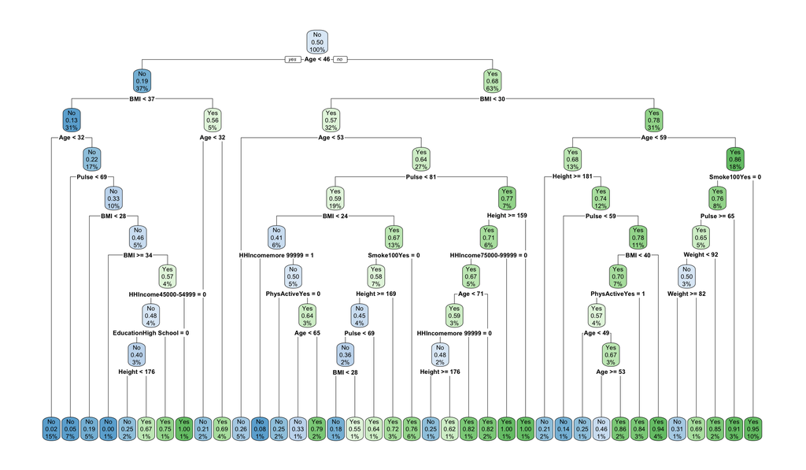

```r
# Plot classification tree
rpart.plot(class_tree$finalModel)
```

```r
# Save results
class_perf = class_tree$results %>% arrange(desc(ROC)) %>%
  slice(1) %>%
  rename(Hyperparameter = "cp")
```

The resulting model found that for the most optimal AUROC of 78.91%, there is a relatively small complexity parameter Cp of 0.001, which suggests that increasing the size and complexity of the tree yields better model performance. We can see that the most important variables in the classification tree in descending order of importance include Age, BMI, and Weight, and as such these are the features that are split near the top of the tree, while lower-importance variables are split near the bottom of the tree.

#### SVC Model

To fit the SVC model, we will train using 10-fold cross-validation, and set the tune grid of length 30 of values ranging from 0.001 to 2. We will also use down-sampling because of a 90/10 imbalance of the outcome variable, Diabetes, in the data.

```r
set.seed(123)

#Set 10-fold cross-validation and downsample
train_control = trainControl(method = "cv", number = 10, sampling = "down", classProbs = T, summaryFunction = twoClassSummary)

#Incorporate different values for cost (C)
mod_svc = train(Diabetes ~ ., data = NHANES_train, method = "svmLinear",  trControl = train_control,
                preProcess = c("center", "scale"),
                tuneGrid = expand.grid(C = seq(0.001, 2, length = 30)),
                metric = "ROC")

# View results from training
mod_svc$results %>% arrange(desc(ROC)) %>% head() %>% knitr::kable()
```

| C | ROC | Sens | Spec | ROCSD | SensSD | SpecSD |
| --- | --- | --- | --- | --- | --- | --- |
| 1.0349655 | 0.8163664 | 0.7176471 | 0.7790472 | 0.0249942 | 0.0285656 | 0.0634597 |
| 1.5864138 | 0.8153885 | 0.7056082 | 0.7921369 | 0.0250822 | 0.0273138 | 0.0626860 |
| 0.6903103 | 0.8149753 | 0.7173978 | 0.7899167 | 0.0233713 | 0.0270027 | 0.0660174 |
| 1.9310690 | 0.8138130 | 0.7201465 | 0.7791397 | 0.0281414 | 0.0343873 | 0.0702719 |
| 0.9660345 | 0.8130726 | 0.7191559 | 0.7660037 | 0.0224252 | 0.0308078 | 0.0576509 |
| 1.3796207 | 0.8128982 | 0.7146377 | 0.7682701 | 0.0266329 | 0.0337501 | 0.0619616 |

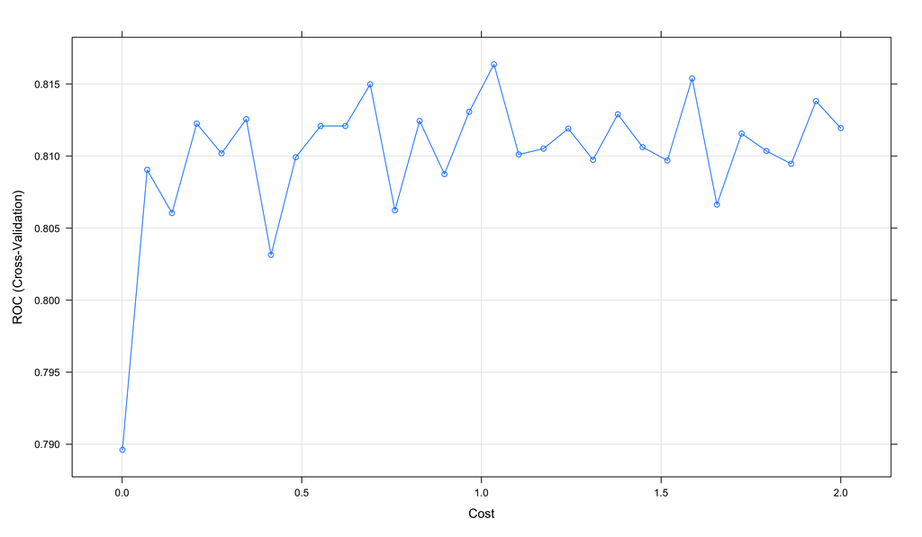

```r
#Visualize accuracy versus values of C
plot(mod_svc)
```

```r
# Save results
svc_perf = mod_svc$results %>% arrange(desc(ROC)) %>%
  slice(1) %>%
  rename(Hyperparameter = "C")
```

For the most optimal AUROC of 81.63%, the the trained SVC model found a hyperparameter (C) of 1.035, allowing a moderate threshold of misclassification between classes. As confirmed by the plot, other values of C from 0.001 to 2 did not optimize the ROC.

#### Logistic Regression Model

To fit the logistic model, we will feed all features into the model, and train within caret on the training dataset.

```r
set.seed(123)
train_control_log = trainControl(summaryFunction = twoClassSummary, classProbs = TRUE)

mod_log = train(Diabetes ~ ., data = NHANES_train, method = "glm", trControl = train_control_log, metric = "ROC")

# View results from training
mod_log$results %>% knitr::kable()
```

| parameter | ROC | Sens | Spec | ROCSD | SensSD | SpecSD |
| --- | --- | --- | --- | --- | --- | --- |
| none | 0.8072741 | 0.9848905 | 0.0823955 | 0.0152555 | 0.0048531 | 0.0239595 |

```r
# Save model results
log_perf = mod_log$results %>% arrange(desc(ROC)) %>% slice(1) %>%
  rename(Hyperparameter = "parameter") %>%
  mutate(Hyperparameter = as.numeric(Hyperparameter))
```

The resulting model yielded an AUROC of 80.73%, with a very high sensitivity of 98.5% but a very low specificity of 8.24%.

#### Comparing performance across models

Finally, let’s compare the performance results on the training data across the 3 models.

```r
rbind(class_perf, log_perf, svc_perf) %>%
  mutate(Model = c("Classification Tree", "Logistic Regression", "SVC")) %>%
  relocate(Model) %>%
  arrange(desc(ROC)) %>%
  knitr::kable(digits = 4)
```

| Model | Hyperparameter | ROC | Sens | Spec | ROCSD | SensSD | SpecSD |
| --- | --- | --- | --- | --- | --- | --- | --- |
| SVC | 1.035 | 0.8164 | 0.7176 | 0.7790 | 0.0250 | 0.0286 | 0.0635 |
| Logistic Regression | NA | 0.8073 | 0.9849 | 0.0824 | 0.0153 | 0.0049 | 0.0240 |
| Classification Tree | 0.001 | 0.7891 | 0.6988 | 0.7531 | 0.0294 | 0.0326 | 0.0576 |

The table shows that the SVC model has the best performance as measured by AUROC (81.64%%), followed by the baseline logistic regression model (80.73%), then the Classification Tree (78.91%). We can see that for the SVC, there is better balance of sensitivity (71.76%) and specificity (77.9%), and while the baseline model has the second highest AUROC, there is a very large imbalance of sensitivity (98.49%) and specificity (8.24%). Therefore, I would choose the SVC as my final model to optimally classify diabetes without an overwhelming imbalance of false positives that would be introduced if I chose the baseline model.

### Step 4: Final Model Evaluation

Finally, we will evaluate the performance our final SVC model by making predictions in the test data. We will use the `confusionMatrix()` function to get performance measures of sensitivity, specificity, NPV, and PPV, and accuracy for the model, and plot the ROC curve.

```r
# Make predictions in test set
pred = mod_svc %>% predict(NHANES_test)
NHANES_test = NHANES_test %>% mutate(pred = as.factor(pred))

# Get evaluation metrics from test set
cm = confusionMatrix(data = NHANES_test$pred, reference = NHANES_test$Diabetes, positive = "Yes")


#Create ROC Curve for Analysis
pred_prob <- predict(mod_svc, NHANES_test, type = "prob")

# Plot Area under the Receiver Operating Curve (AUROC)
analysis =  roc(response = NHANES_test$Diabetes, predictor = pred_prob[,2])

# View results
cm
```

```
## Confusion Matrix and Statistics
##
##           Reference
## Prediction   No  Yes
##        No  1222   36
##        Yes  487  161
##
##                Accuracy : 0.7256
##                  95% CI : (0.705, 0.7455)
##     No Information Rate : 0.8966
##     P-Value [Acc > NIR] : 1
##
##                   Kappa : 0.2645
##
##  Mcnemar's Test P-Value : <2e-16
##
##             Sensitivity : 0.81726
##             Specificity : 0.71504
##          Pos Pred Value : 0.24846
##          Neg Pred Value : 0.97138
##              Prevalence : 0.10336
##          Detection Rate : 0.08447
##    Detection Prevalence : 0.33998
##       Balanced Accuracy : 0.76615
##
##        'Positive' Class : Yes
##
```

```r
analysis$auc
```

```
## Area under the curve: 0.8235
```

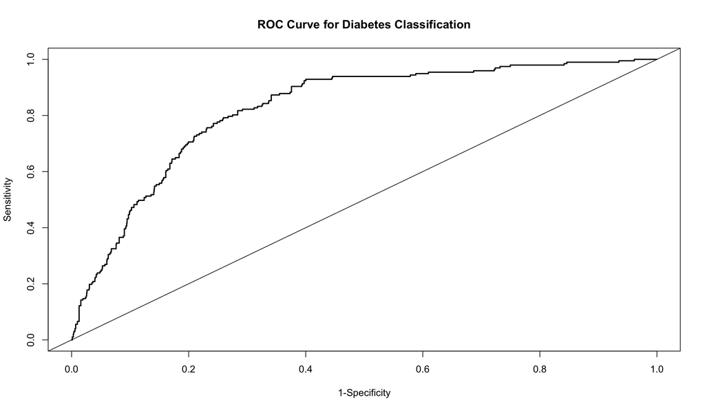

```r
plot(1 - analysis$specificities, analysis$sensitivities, type = "l",
ylab = "Sensitivity",xlab = "1-Specificity", col = "black", lwd = 2,
main = "ROC Curve for Diabetes Classification")
abline(a = 0, b = 1)
```

On the testing set, we can see that the AUROC of our final model is 82.35%, with accuracy of 72.56%, sensitivity of 81.73%, and specificity of 71.5%. Moreover, we see a large imbalance between the PPV (24.85%) and NPV (97.14%), which may be affected due to low prevalence (10.34%) of diabetes cases in the data such that there is a much higher probability of truly detecting persons without diabetes.

### SVC Model Limitations

One main consideration that arose was the imbalance of cases and controls in the NHANES data that we used to train the model on, where there were a disproportionate number of cases without diabetes compared to those with diabetes. With imbalanced data, information required to make an accurate prediction about the minority class is limited, and therefore when applied to new data, the model may not perform well when trying to predict new cases of diabetes. Although we dealt with this issue by downsampling while training our model, we saw a lower PPV, and this limitation is what we may expect when applying the algorithm on new data with a low prevalence of diabetes.

Another limitation of the SVC model is that it does not inherently perform feature selection, and therefore may result in limited prediction performance and overfitting on new datasets because of irrelevant features that were included in the model when training on the original data. As such, there can be limitations when applying this model on large datasets or high-dimensional feature spaces. Moreover, depending on what types of applications the SVC model is used for, there are also limitations to the model’s interpretability.